# Linear optics

Many optical applications work at a scale where the image formation process is very linear. Understanding linearity is important for understanding such conventional imaging systems. The principles show up in many places and guide how we think about many optics principles.

This script explores general linearity of image formation. To make the calculations a bit more interesting, we consider a simple camera that does not even have a lens. There is a sensor whose aperture is covered by some scratchy glass. Here is a picture of the rig.

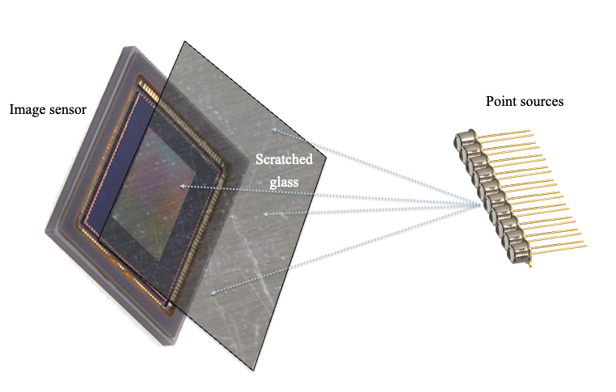

For the stimulus, we first consider a linear array of LEDs light sources. Each LED is a small point source. It emits light in many directions, passing through the scratchy glass and ultimately forming a reasonably meaningless image at the sensor. We can control the intensity of the LEDs separately.

The question is this: What can we learn from the sensor response about the intensity of the different point sources? Even with this 'lensless' system.

### The lights and the sensor

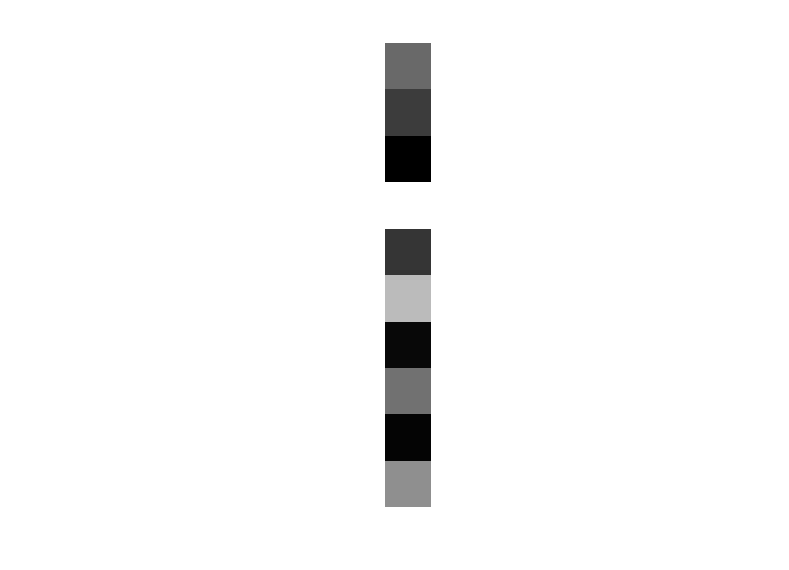

```matlab
% Let's start with just 10 LEDs in a line.
% We initalize their intensity randomly, between 0 and 1.
ledIntensities = rand(10,1);
nPnts = numel(ledIntensities);

% Here is an image of the LEDs
ieFigure;
imagesc(ledIntensities);
colormap("gray"); axis image; axis off;
```

### The sensor image for each LED

The image on the sensor will be a noisy mess, nothing recognizable. The expected sensor response will pretty much be random noise, reflecting the scratches and absence of any focus. The image from each of the different LEDs will also be different because they are coming from a different position in space.

We call the image from each of the LEDs their Point Spread Function (PSF). There is a different PSF for each position. We specify the PSF assuming we have an LED of 'unit' intensity.

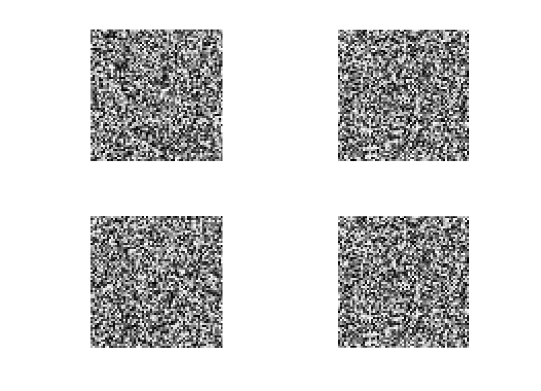

```matlab
% Suppose the sensor has 64 rows and 64 columns
row = 64; col = 64;
PSF = zeros(row,col,nPnts);
for ii=1:nPnts
    PSF(:,:,ii) = rand(row,col,1);
end

ieFigure;
tiledlayout(2,2);
% Here is a sample of some of the PSFs.
for ii = randi(nPnts,[1,4])
    nexttile;
    imagesc(squeeze(PSF(:,:,ii)));
    colormap("gray"); axis image; axis off;
end
```

### The whole image

Here are two important facts.

- If we scale the intensity of an LED, the image is just a scaled version of its PSF.
- The image formed by turning on two LEDs is equal to the sum of the images when we turn each one separately.

Thus, we can calculate the expected image by adding up the individual PSFs, weighted by the led intensities. It is convenient to calculate this sum using a matrix. We 'vectorize' the PSFs, placing each PSF in the column of a matrix.

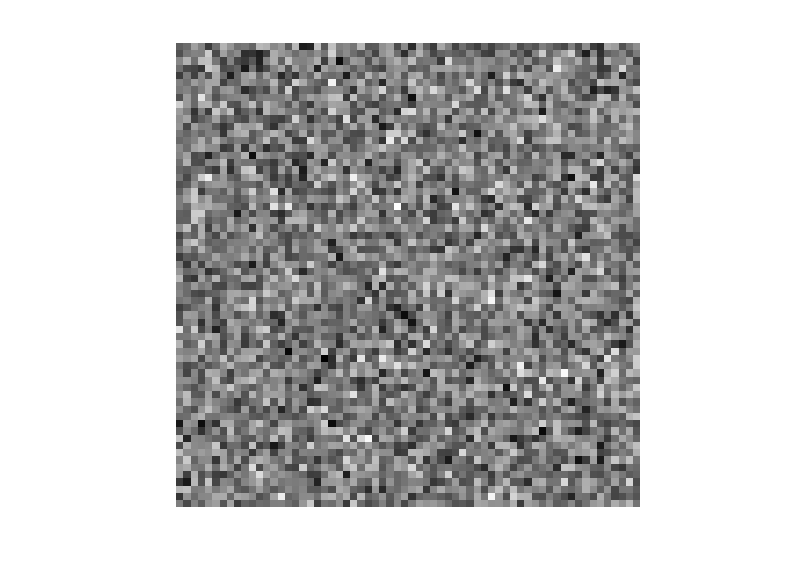

```matlab
% Vectorizing the PSFs
vPSF = reshape(PSF,row*col,nPnts);

% Then we multiply each column by the intensity of its LED.
sensor = vPSF*ledIntensities(:);

% Here is what the image looks like.  (We have to reshape to see it as an
% image)
ieFigure;
imagesc(reshape(sensor,row,col));
colormap("gray"); axis off; axis image;
```

### Estimate the input image from the output image.

The equation for the sensor image is linear. We vectorize the PSFs, placing them in the columns. We multiply the columns by the led intensities.

$sensor = vPSF * ledIntensities$

To estimate the led intensities from the sensor response, we only need to invert the equation. The estimated LED intensities are returned this way.

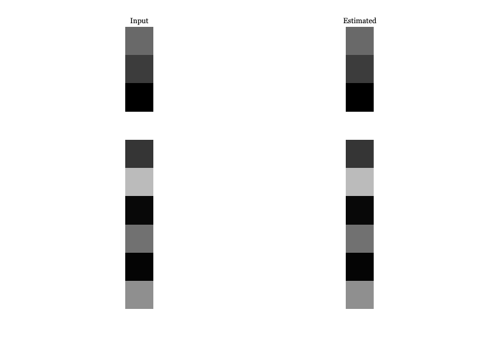

```matlab
% This is Matlab's way of solving the linear equation.  It is equivalent to
% a pseudoinverse, which would like like this:
%
%      estLED = inv(vO'*vO)*(vO') sensor
%
ieFigure;
tiledlayout(1,2);
nexttile
imagesc(ledIntensities);
colormap(gray); axis image; axis off; subtitle('Input')

nexttile
estLEDintensities = vPSF\sensor;
imagesc(estLEDintensities);
colormap(gray); axis image; axis off; subtitle('Estimated')
```

### How did we do?

We can plot the estimated LED intensities and the true intensities

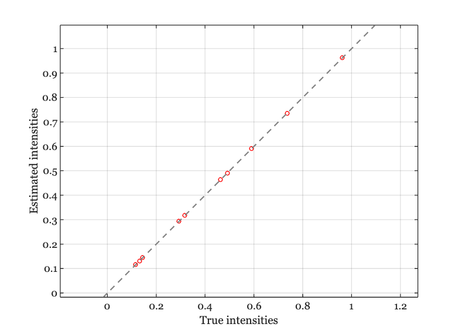

```matlab
ieNewGraphWin;
plot(ledIntensities(:),estLEDintensities(:),'o');
xlabel('True intensities');
ylabel('Estimated intensities')
grid on; axis equal; identityLine;
```

### Let's scale it up

Suppose we have more LEDs so we can make a pattern. Say 256. Would the method still work? Let's create a pattern of LEDs that form an image of an X. We will make each of the intensities in the lines a little random, just to keep life interesting.

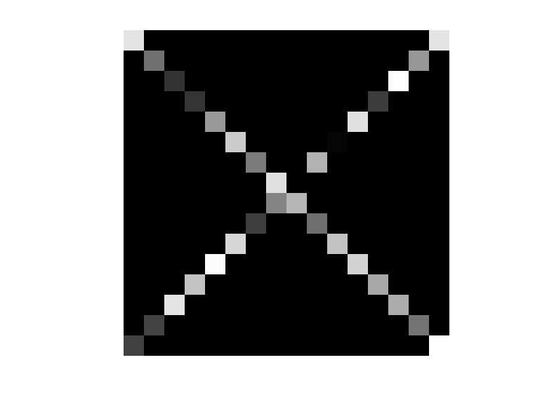

```matlab
% The spatial array of the LEDs
row = 16; col = 16;
ledIntensities = zeros(row,col);
nPnts = numel(ledIntensities);

% Make an X with random intensities
for ii=1:row, ledIntensities(ii,ii) = rand(1); end
for ii=1:row, ledIntensities((row+1)-ii,ii)= rand(1); end
imagesc(ledIntensities); colormap("gray"); axis off; axis image;
```

## We have more points, so we need more PSFs.

The recovery works best (surprisingly?) when the PSFs are random vectors. If you make them more correlated, say by using this code snippet instead,

thisGaussian = fspecial("gaussian",[row,col],spread(ii));

img(:) = 0;

img(ii) = 1;

PSF(:,:,ii) = conv2(img,thisGaussian,'same');

the sensitivity to noise and recovery becomes worse.

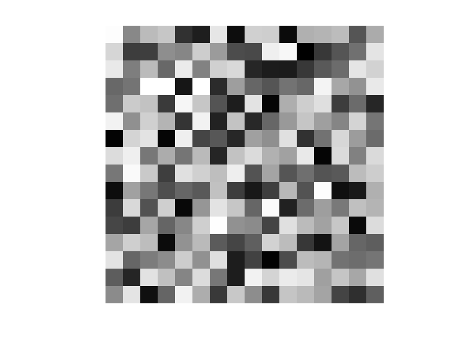

```matlab
% Create some example PSFs
PSF = zeros(row,col,nPnts);
img = zeros(row,col);

spread = randi(row/8,[row,col]);
for ii=1:nPnts
    PSF(:,:,ii) = rand(row,col,1);
end

% Here are a few of the PSFs.  Random, again.
for ii=1:(row+2):nPnts
    imagesc(PSF(:,:,ii));
    colormap("gray"); axis image; axis off;
    pause(0.1);
end
```

### Form the image

The image looks like complete noise, of course.

```matlab
vPSF = reshape(PSF,row*col,nPnts);

% Then we multiply each column by the intensity of its LED.  We have to
% vectorize the LED intensities.
sensor = vPSF*ledIntensities(:);
```

noiseLevel = 0.001;

sensor = sensor + max(sensor(:))*noiseLevel*randn(size(sensor));

fprintf('Adding sensor noise at level %.3f\n',noiseLevel);

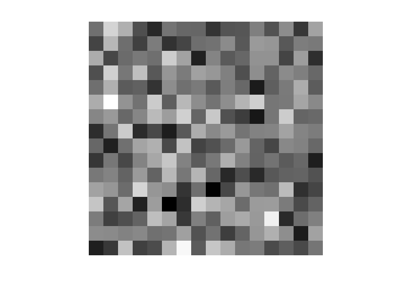

```matlab
% The sensor image.
imagesc(reshape(sensor,row,col));
colormap("gray"); axis off; axis image;
```

## The LED estimate

We can still estimate the original - though this is not a great way to do the inverse estimate. There are better ones.

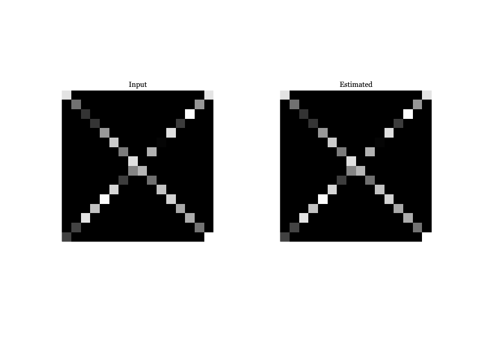

```matlab
estLEDintensities = vPSF\sensor;

ieFigure;
tiledlayout(1,2);
nexttile;
imagesc(ledIntensities); colormap(gray); axis image; axis off; subtitle('Input')
nexttile;
imagesc(reshape(estLEDintensities,row,col)); colormap(gray); axis image; axis off;subtitle('Estimated')
```

### How did we do?

A scatter plot of the estimated LED intensities and the true intensities falls along the identity line. That's good!

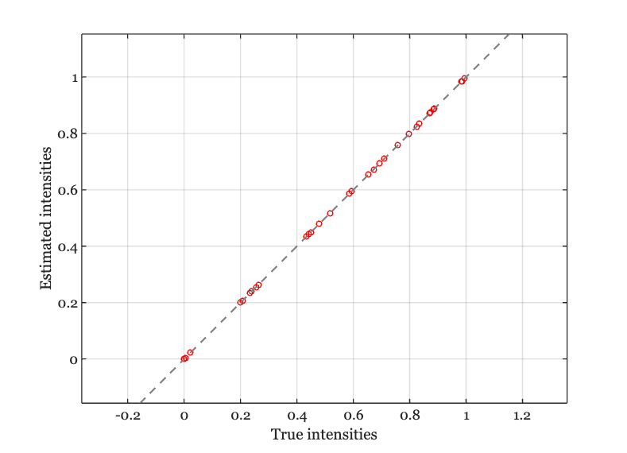

```matlab
ieNewGraphWin;
plot(ledIntensities(:),estLEDintensities(:),'o');
xlabel('True intensities');
ylabel('Estimated intensities')
grid on; axis equal; identityLine;
```

Even though the image at the sensor looks like noise, we can recover the original image from it. We just need to now each of the point spread functions of the LEDS.

To see how this approach breaks, try adding some noise to the image.